# Trophic_class

Vianney DENIS

2023-09-29

# Analysing stable isotope data in R

## Background

### Who am I

Vianney Denis, Coral Reef Ecologist, National Taiwan University A (too) broad interest on coral reefs from physiological ecology to ecosystem ecology.

### R and stable isotope data

You are probably already familiar or already probably heard about R. You may not be proficient in using it, and the aim of this class is to introduce some common and more advanced tools to analyse stable isotope in the field of trophic ecology. This class will not come back on general knowledge of what is an isotope and how they can be useful for ecology (see previous courses), but it will focus on more technical details which are how we analyse the data. In particular, we will navigate in R packages/functions allowing to visualize stable isotope data and we will go through common R packages used in trophic ecology.

I will use Posit (ex RStudio) for the demo. If you have it installed on your computer, you can use it but make sure it is updated with the latest version of R/Posit. This class has also been optimized for a use with **posit** Cloud. You can register and use it for free with, of course, some limitation on computing time (25 hrs) and RAM (1GB). That should be okay largely enough for two days if you close it after the class.

GUI of Posit/RStudio is pretty standard: script editor, console, environment, files - plots - packages windows. That’s all we need for now.

### R Markdown to load and plot data

We’ll use this to compile and store all the r code used during the class. This way you can edit and improve the scripts as you go on and even copy relevant sections for other projects. This markdown is being saved as a html document but you can also open the markdown directly as you see on my screen.

Now we need to install and load the packages we will be using during the workshop. You can use the Packages wizard in posit (bottom right) to install each of these and then load them all using the following chuck of code. It is going to give you a few messages to let you know some info about the package versions but also if their is any problems with them

```r
library (ggplot2) # data visualization
library(GGally) # data visualization
library (reshape2) # data manipulation
library(plyr) # data manipulation
library(tidyr) # data manipulation
library(dplyr) # data manipulation
library(splancs) # display and analysis of spatial point pattern data
library(R2WinBUGS) # Bayesian analysis
library(SIBER) # trophic niche
library(MixSIAR) # mixing model
```

### Data availability

All data and code to replicate the analysis here are provided [here](https://github.com/vianneydenis/trophic-ecology.git). You can use this repository and knit the .Rmd file. Edits, suggestions, and comments are welcome.

### Credit

To **Brian Hayden** (https://sites.google.com/view/brianhayden/home?authuser=0) Amazing series of videos on trophic ecology and stable isotope analysis on his website. Most of the content of this class is taken and adapted from his available teaching material. If you enjoy this class, visit his website and his YouTube channel.

## Data overview and familiarisation

### Preliminary data interrogation

Here we will load in an isotope dataset and have a look for outliers and other issues we need to be concerned about.

First load the data associated with this workshop (the file is named *Dataset*). We will manipulate and transform this dataset as we work) This file contains carbon and nitrogen data for two coral species (one black coral and one gorgonian coral) and their possible food sources. Part of the data are published and available at: https://www.sciencedirect.com/science/article/pii/S0272771418310606

Generally speaking, your data should already have been tidied up, probably in Excel, so you removed any of the additional lines at the start that often come back from analytical laboratories. R uses ‘raw’ format. It means you need to keep your datasheet very simple (no color or any other fancy format). Just be boring, that’s good for R. As with all data files, your first line (row) should be the names of each of the columns. When naming columns, it is important to not use any unusual, non-standard characters, as these can confuse the functions that are parsing (reading and processing) the data file: if you need to separate words in a column header you should use “_” or “.”, e.g. “delta_C” or “delta.C” but not “delta/C”. It is generally not recommended to have spaces.

```r
# Load your data
Dataset <- read.csv("Data/Dataset.csv") # Import a file

#View the first 10 rows of data
head(Dataset) # see the head
```

```
##   Reference             Date_Station_Type       Date   Station    Other
## 1         1 01/08/2016_Station_1_filter_1   1/8/2016 Station 1 filter 1
## 2         3 01/08/2016_Station_2_filter_1   1/8/2016 Station 2 filter 1
## 3         5 01/08/2016_Station_3_filter_1   1/8/2016 Station 3 filter 1
## 4         7 23/08/2016_Station_1_filter_1 23/08/2016 Station 1 filter 1
## 5         9 23/08/2016_Station_2_filter_1 23/08/2016 Station 2 filter 1
## 6        11 23/08/2016_Station_3_filter_1 23/08/2016 Station 3 filter 1
##                Type          Category Season d15N  d13C Weight   mgN   mgC
## 1 pico-nanoplankton pico-nanoplankton autumn  3.4 -23.5   10.1 0.006 0.040
## 2 pico-nanoplankton pico-nanoplankton autumn  3.1 -23.8   10.1 0.006 0.042
## 3 pico-nanoplankton pico-nanoplankton autumn  2.8 -23.9    9.6 0.005 0.037
## 4 pico-nanoplankton pico-nanoplankton autumn  3.4 -23.2   10.8 0.006 0.044
## 5 pico-nanoplankton pico-nanoplankton autumn  5.5 -23.9   10.6 0.009 0.054
## 6 pico-nanoplankton pico-nanoplankton autumn  5.6 -23.5   11.2 0.008 0.047
##      RunNo
## 1 170912DF
## 2 170912DF
## 3 170912DF
## 4 170912DF
## 5 170912DF
## 6 170912DF
```

```r
# Make a simplified dataset
Data <- Dataset # Make a copy of the object
Data$CN <- (Data$mgC/Data$Weight*100)/(Data$mgN/Data$Weight*100) # Compute CN ratio
Data[,c("Reference", "Date_Station_Type", "Date", "Station", "Other", "RunNo" )] <-NULL # add NULL in the useless variables
head(Data)
```

```
##                Type          Category Season d15N  d13C Weight   mgN   mgC
## 1 pico-nanoplankton pico-nanoplankton autumn  3.4 -23.5   10.1 0.006 0.040
## 2 pico-nanoplankton pico-nanoplankton autumn  3.1 -23.8   10.1 0.006 0.042
## 3 pico-nanoplankton pico-nanoplankton autumn  2.8 -23.9    9.6 0.005 0.037
## 4 pico-nanoplankton pico-nanoplankton autumn  3.4 -23.2   10.8 0.006 0.044
## 5 pico-nanoplankton pico-nanoplankton autumn  5.5 -23.9   10.6 0.009 0.054
## 6 pico-nanoplankton pico-nanoplankton autumn  5.6 -23.5   11.2 0.008 0.047
##         CN
## 1 6.666667
## 2 7.000000
## 3 7.400000
## 4 7.333333
## 5 6.000000
## 6 5.875000
```

It is not so easy to get summary statistics on each category within our data set using the basic R functions. There are many packages out there to help, but Hadley Wickham’s suite of packages are impossible to beat, and we will be using his `ggplot2` package for pretty graphs later.Let’s stick with the [“Hadleyverse”](https://www.tidyverse.org/) of functions. We installed `ggplot2` and `tidyr` packages, but the complete tidyverse collection can directly be installed at once with: `install.packages("tidyverse")`.

```r
# Some quick summary
## all categories
Data.sum.1<-ddply(Data, c("Season", "Category"), summarise,
                count = length(Category),
                mC = round(mean(d13C, na.rm=T), digits=1), sdC = round(sd(d13C, na.rm=T), digits=1),
                mN = round(mean(d15N, na.rm=T), digits=1), sdN = round(sd(d15N, na.rm=T), digits=1))
head(Data.sum.1)
```

```
##   Season          Category count    mC sdC  mN sdN
## 1 autumn      A_subpinnata    12 -21.3 0.4 6.0 0.3
## 2 autumn        E_cavolini     7 -15.8 1.1 5.6 0.1
## 3 autumn      mesoplankton    29 -21.5 0.9 3.5 0.7
## 4 autumn     microplankton    15 -24.1 0.5 6.3 1.7
## 5 autumn pico-nanoplankton    15 -23.4 0.5 3.1 1.4
## 6 autumn          sediment     9  -1.6 3.2 3.4 0.8
```

```r
## coral only
Coral<-subset(Data, Type == "coral")
Coral.sum.1<-ddply(Coral, c("Season", "Category"), summarise,
                count = length(Category),
                mC = round(mean(d13C), digits=1), sdC = round(sd(d13C), digits=1),
                mN = round(mean(d15N), digits=1), sdN = round(sd(d15N), digits=1))
Coral.sum.1
```

```
##   Season     Category count    mC sdC  mN sdN
## 1 autumn A_subpinnata    12 -21.3 0.4 6.0 0.3
## 2 autumn   E_cavolini     7 -15.8 1.1 5.6 0.1
## 3 spring A_subpinnata    12 -21.9 0.2 6.1 0.2
## 4 spring   E_cavolini     8 -14.3 1.6 5.9 0.2
```

Here, it is important to notice how managed here the missing data (`NA`) as it will influence later visualization and analysis. Also note that for stable isotope values, you should reduce decimal to match resolution of the mass spectrometer.

There is quite a bit here but we can also use subset of the data set.

```r
# A subset of the data set
A_subpinnata_spring<-subset(Data, Category == "A_subpinnata" | Season == "spring")
head(A_subpinnata_spring)
```

```
##                 Type          Category Season d15N  d13C Weight   mgN   mgC
## 16 pico-nanoplankton pico-nanoplankton spring   NA -23.8   10.1 0.006 0.041
## 17 pico-nanoplankton pico-nanoplankton spring  1.7 -24.0   10.7 0.007 0.050
## 18 pico-nanoplankton pico-nanoplankton spring   NA -24.0   12.0 0.007 0.053
## 19 pico-nanoplankton pico-nanoplankton spring  4.0 -22.8   12.0 0.009 0.066
## 20 pico-nanoplankton pico-nanoplankton spring  7.6 -23.2   10.7 0.007 0.051
## 21 pico-nanoplankton pico-nanoplankton spring  6.4 -23.5    9.2 0.005 0.039
##          CN
## 16 6.833333
## 17 7.142857
## 18 7.571429
## 19 7.333333
## 20 7.285714
## 21 7.800000
```

### Basic Visualisation

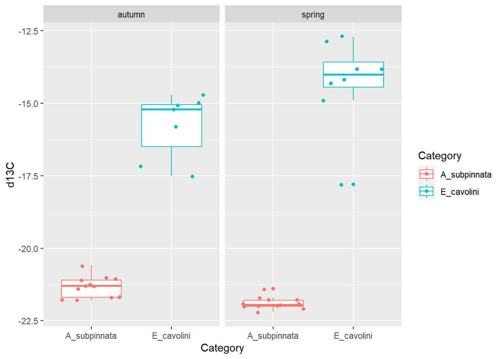

```r
# Plotting isotope data: d13C only (or any other variable)

New.data<-subset(Data, Category == "A_subpinnata" | Category == "E_cavolini")

Iso.boxplot<-ggplot(New.data, aes(x=Category, group = Category, y=d13C, colour=Category)) +
  geom_boxplot() +
  geom_point(position="jitter")+
  facet_grid(. ~ Season)

Iso.boxplot
```

```r
ggsave("Plots/d13C.pdf")
```

What about the other variables… 15N, C/N, etc.

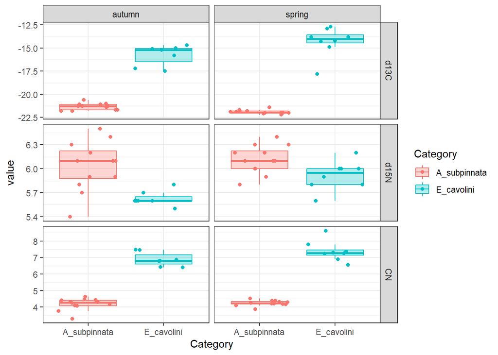

```r
# Plotting isotope data: All at once with a step of melting and faceting the data set

Melt.data<-melt(New.data, measure.vars  = c("d13C", "d15N", "CN"), variable.name= "variable", value.name="value") # idvar to explain

Melt.boxplot<-ggplot(Melt.data, aes(x=Category, group = Category, y=value, colour=Category, fill=Category)) +
  geom_boxplot(alpha=0.3, outlier.shape = NA) +
  geom_point(position="jitter") +
  facet_grid(variable ~ Season, scales = "free_y") +
  theme_bw()

Melt.boxplot
```

You can also save this plot because it is beautiful.

*Inorganic Carbon and lipid effects*

- Carbonate: At first, we may want to test whether there is evidence for an effect of inorganic carbon on the carbon isotope values. If this was a factor we would expect to see a positive relationship between %C and d13C. Here, the d13C data we got are already from samples that have been acidified and in which carbonates have been remove. Yet, for the fun we can make the plot:

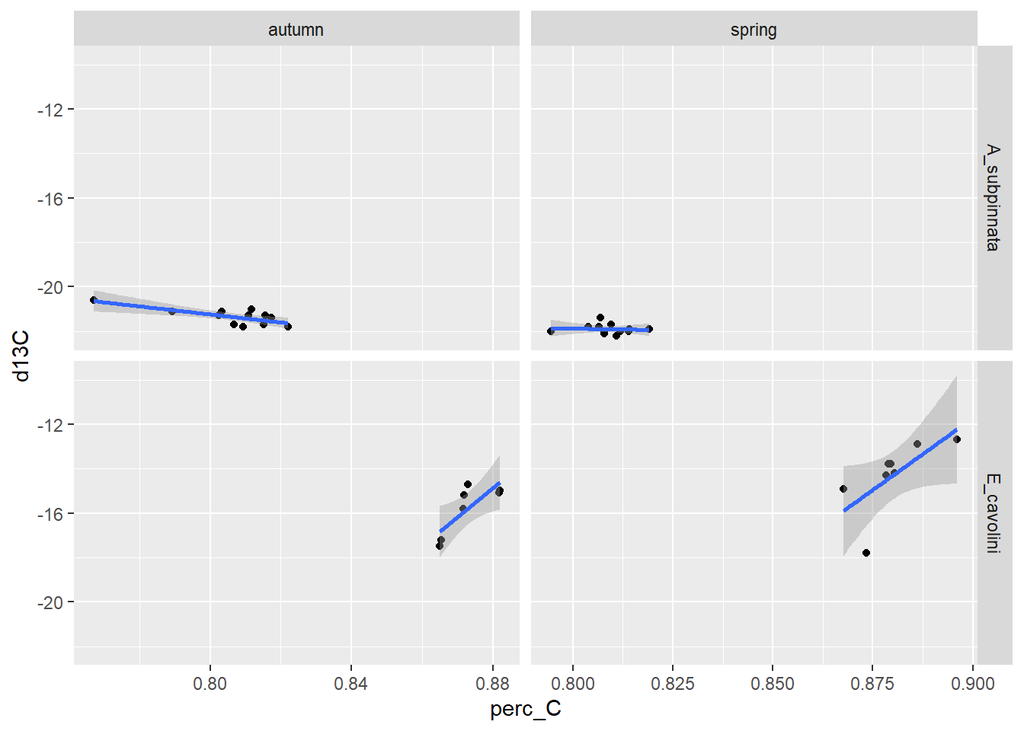

```r
# Carbonate effect

New.data$perc_C<-New.data$mgC/(New.data$mgC+New.data$mgN)

Carbonate.plot<-ggplot(New.data, aes(x=perc_C, y=d13C)) +
  geom_point() +
  geom_smooth(method = "lm", se=T,formula=y~x) +
  facet_grid(Category ~ Season, scales = "free_x")

Carbonate.plot
```

Samples have been acidified and inorganic carbon removed.

- Lipid: As a general rule, lipids contain carbon but no nitrogen AND are 13C depleted relative to protein (i.e. muscle). So, lipid rich samples will be depleted in 13C, in extreme cases this may bias our interpretation of their position in the food web.

Pure protein has an elemental C:N ratio of 3 (2.8 - 3.2), C:N values above this are indicative of lipids in the matrix. There are two options to deal with this: you can remove lipids from the sample using repeated washes in a 2:1 chloroform:methanol solution or using a lipid correction model (not suitable for invertebrates). For corals, well that’s complicated. C:N values are generally much higher.

We can look at this relationship in two ways. First let’s test whether there is a relationship between C:N and d13C in our samples. What relationship would we expect if lipid was having an effect on the d13C values of the coral?

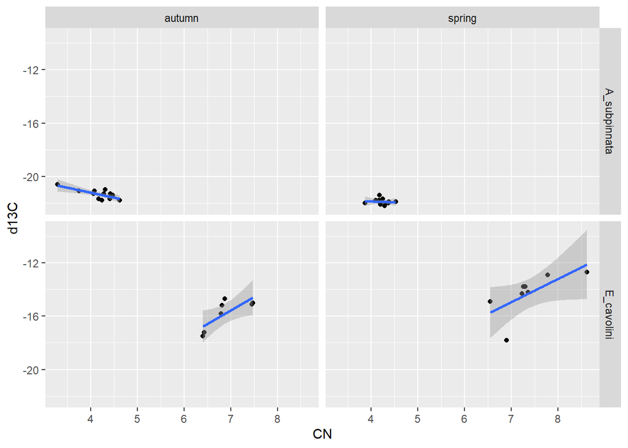

```r
# Lipid effect raw
Lipid.plot<-ggplot(New.data, aes(x=CN, y=d13C)) +
  geom_point() +
  geom_smooth(method = "lm", se=T,formula=y~x) +
  facet_grid(Category ~ Season)

Lipid.plot
```

Alternatively we can identify whether any individuals / populations have C:N values above a threshold. A CN ratio of 7 is common for corals ([Fujii et al. 2020](https://www.mdpi.com/2076-2607/8/8/1221); [Hoegh-Guldberg et al. 2004](https://www.int-res.com/abstracts/meps/v280/p105-114/); [Hsu et al. (2020)](https://www.frontiersin.org/articles/10.3389/fmars.2020.606601/full?ref=https://githubhelp.com); [Sturaro et al. (2019)](https://besjournals.onlinelibrary.wiley.com/doi/full/10.1111/1365-2435.13924))

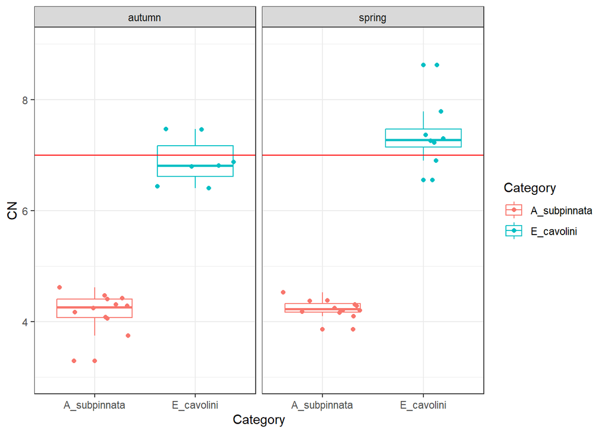

```r
# Lipid effect threshold
Lipid.boxplot<-ggplot(subset(Data, Type == "coral"), aes(x=Category, group = Category, y=CN, colour=Category)) +
  geom_boxplot() +
  geom_point(position="jitter")+
  ylim(3,9) +
  geom_hline(aes(yintercept=7), colour="red") +
  facet_grid(. ~ Season) +
  theme_bw()

Lipid.boxplot
```

Lipid removal may have been beneficial, but in corals C:N is generally high independently of lipid removal. This is also taxon specific, so some preliminary test are usually advised. Know your beast ! There is a lot of literature on the topic. Among others, check [Sturaro et al. (2019)](https://analyticalsciencejournals.onlinelibrary.wiley.com/doi/full/10.1002/rcm.8663) and its supplementary information for a details methodology.

We went through these comparisons individually here, but you can use pairs plots to summarize much of this information. As ever, there is a ‘Hadleyverse’ option, `ggpairs`, in the GGally package. These are coarse plots but an excellent way to take a first look at your data.

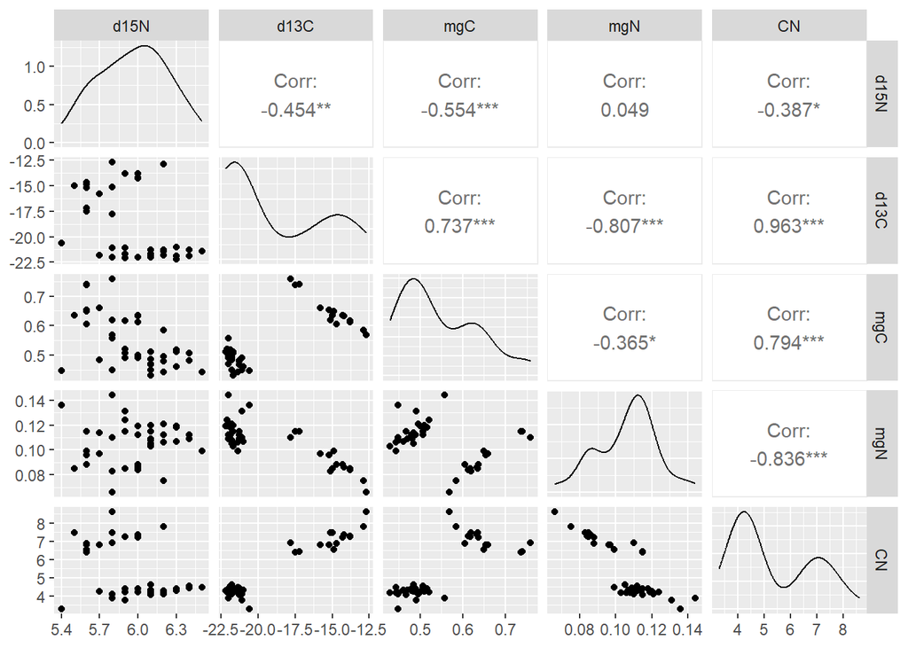

```r
# Pair plot
ggpairs(New.data[,c("d15N","d13C", "mgC", "mgN", "CN")])
```

### Stable isotope biplot

Once we are happy that our data are robust we can move on to some preliminary plots and interrogation. The standard way to view isotope data is though a biplot with a source isotope (carbon, hydrogen or sulphur) on the x-axis and nitrogen on the y-axis. In this instance we are plotting carbon and nitrogen data for various corals and food sources.

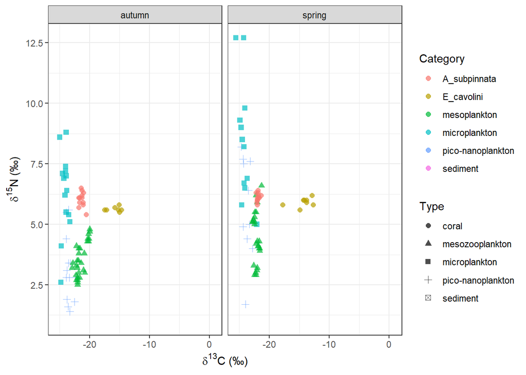

```r
# Raw biplot
Iso.biplot<-ggplot(Data, aes(x = d13C, y = d15N, colour = Category, shape = Type)) +
  geom_point(alpha = 0.7, size=2) +
  facet_grid(. ~ Season) +
  theme_bw() +
  ylab(expression(paste(delta^{15}, "N (\u2030)"))) +
  xlab(expression(paste(delta^{13}, "C (\u2030)")))

Iso.biplot
```

```r
ggsave("Plots/Iso_biplots.pdf")
```

```
## Warning: Removed 23 rows containing missing values (`geom_point()`).
```

Here the warning is important as it indicates that you have missing data. As for an examples, none of the sediment samples were measured for both d15N and d13C. The x- and y-axes will be adjusted according to these values but no data will be plotted.

Finally lets look at a summary biplot for both seasons

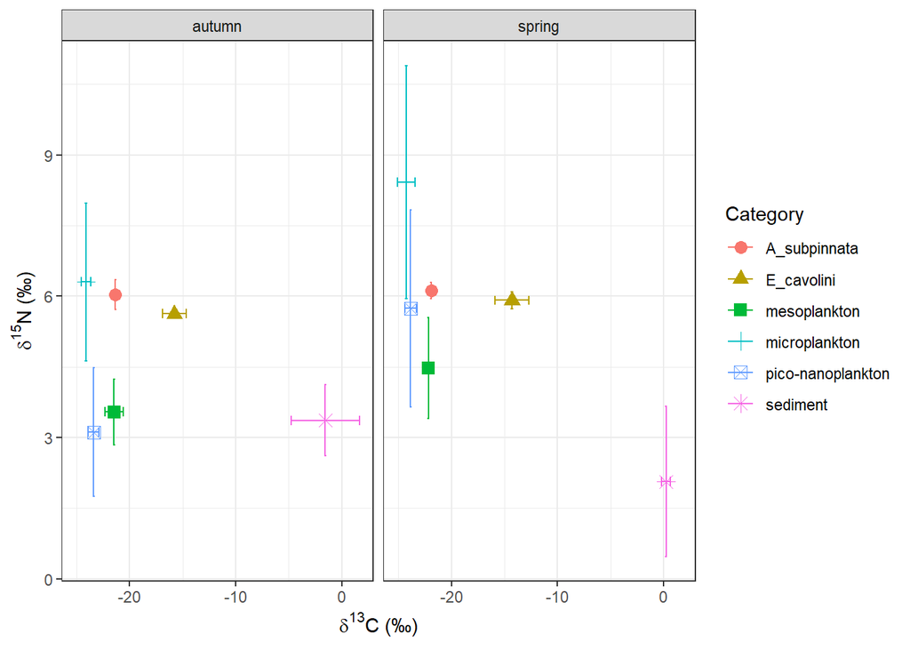

```r
# Summary biplot
Data.sum<-ddply(Data, c("Season", "Category"), summarise,
                d13Cmn=mean(d13C, na.rm=T), # mean
                d13Csd=sd(d13C, na.rm=T),#standard deviation
                d13Cse=sd(d13C, na.rm=T)/sqrt(length(Data$d13C[!is.na(Data$d13C)])), #standard error
                d15Nmn=mean(d15N, na.rm=T),
                d15Nsd=sd(d15N, na.rm=T),
                d15Nse=sd(d15N, na.rm=T)/sqrt(length(Data$d15N[!is.na(Data$d15N)])))

Ylims <- aes(ymax = d15Nmn + d15Nsd, ymin=d15Nmn - d15Nsd)
Xlims <- aes(xmax = d13Cmn + d13Csd, xmin=d13Cmn - d13Csd)

Sum.biplot<-ggplot(Data.sum, aes(x=d13Cmn, y=d15Nmn, colour=Category, shape =Category)) +
  geom_point(size=3) +
  geom_errorbar(Ylims, width=0.2) +
  geom_errorbarh(Xlims, height=0.2) +
  ylab(expression(paste(delta^{15}, "N (\u2030)"))) +
  xlab(expression(paste(delta^{13}, "C (\u2030)"))) +
  facet_grid(. ~ Season)+
  theme_bw()

Sum.biplot
```

```r
ggsave("Plots/Sum_biplot.pdf")
```

The initial question in study was whether *A. subpinnata* and *E. cavolini* used different resources (i.e. had different isotope ratios) in the two seasons. Do they? Lets start with a biplot to visualize the difference between the two coral species.

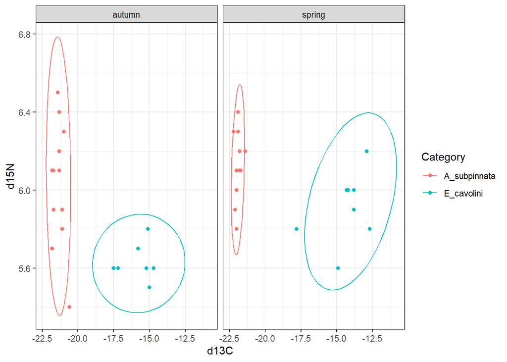

```r
# Coral biplot
Coral.biplot<-ggplot(subset(Data, Category == "A_subpinnata" | Category == "E_cavolini"), aes(x=d13C, y=d15N, colour = Category)) +
  geom_point() +
  stat_ellipse() + # 95%
  facet_grid(. ~ Season)+
  theme_bw()

Coral.biplot
```

```r
ggsave("Plots/Coral_biplot.pdf")
```

## Mixing models

### Basic mixing models - two sources

We can see that the species have different isotope ratios but what does this mean? To infer trophic ecology from ‘raw’ isotope data.

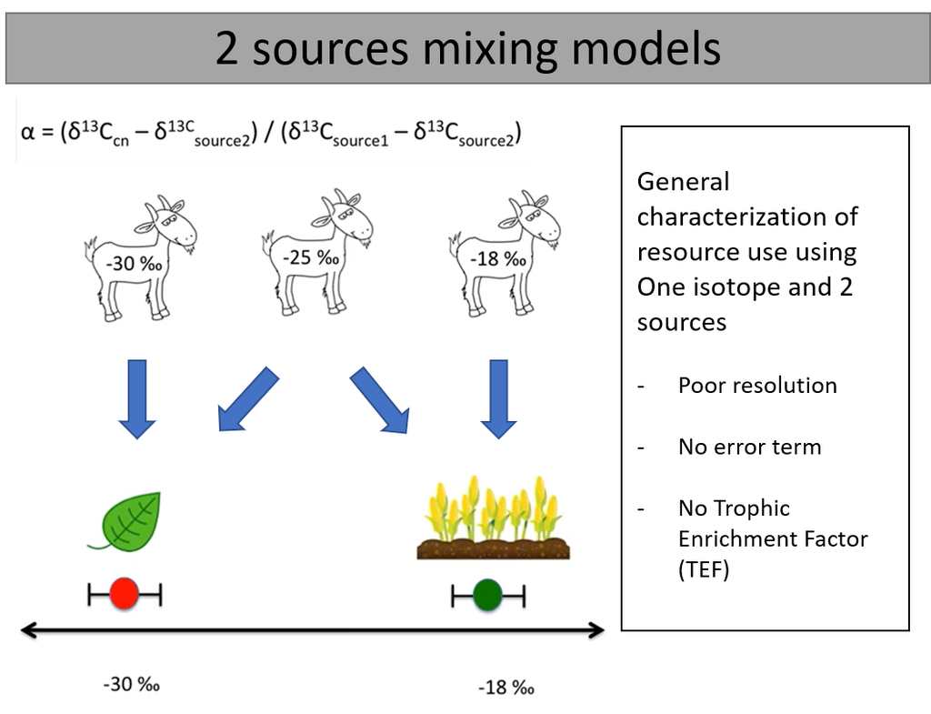

Two sources mixing model explained - Adapted from Snowy illustration by Brian Hayden

The first step is to identify the baseline values. Here we will use pico-nanoplanton and POM (sediment) as pelagic/oceanic and littoral/coastal end-members respectively.

```r
# Endmember selection
endmembers.sum<-Data.sum.1
PNP<-subset(endmembers.sum, Category == "pico-nanoplankton")
POM<-subset(endmembers.sum, Category == "sediment")
Season<-c("autumn", "spring")
d13Cpel<-c(-23.4, -23.8)
d15Npel<-c(3.1, 5.7)
d13Clit<-c(-1.6, 0.2)
d15Nlit<-c(3.4, 2.1)
endmembers<-data.frame(Season, d13Cpel, d15Npel, d13Clit, d15Nlit)
mm.data<-merge(Data, endmembers, by = "Season")
head(mm.data)
```

```
##   Season              Type          Category d15N  d13C Weight   mgN   mgC
## 1 autumn pico-nanoplankton pico-nanoplankton  3.4 -23.5   10.1 0.006 0.040
## 2 autumn pico-nanoplankton pico-nanoplankton  3.1 -23.8   10.1 0.006 0.042
## 3 autumn pico-nanoplankton pico-nanoplankton  2.8 -23.9    9.6 0.005 0.037
## 4 autumn pico-nanoplankton pico-nanoplankton  3.4 -23.2   10.8 0.006 0.044
## 5 autumn pico-nanoplankton pico-nanoplankton  5.5 -23.9   10.6 0.009 0.054
## 6 autumn pico-nanoplankton pico-nanoplankton  5.6 -23.5   11.2 0.008 0.047
##         CN d13Cpel d15Npel d13Clit d15Nlit
## 1 6.666667   -23.4     3.1    -1.6     3.4
## 2 7.000000   -23.4     3.1    -1.6     3.4
## 3 7.400000   -23.4     3.1    -1.6     3.4
## 4 7.333333   -23.4     3.1    -1.6     3.4
## 5 6.000000   -23.4     3.1    -1.6     3.4
## 6 5.875000   -23.4     3.1    -1.6     3.4
```

We now have a data frame where each row contains the d13C and d15N values of a specific consumer, in addition to pelagic and littoral baseline values for the relevant season We can use a 2 source mixing model to derive the relative contribution of each baseline to the consumer. The mixing model described by Post is:

alpha (i.e. the relative contribution of base 1 to the consumer) = (d13C of the consumer - d13C of base 2) / (d13C of base 1 - d13C of base 2)

We can code this as:

```r
# Resource boxplot raw
mm.data$PEL<-(mm.data$d13C - mm.data$d13Clit) / (mm.data$d13Cpel - mm.data$d13Clit)
mm.data$PEL<-round(mm.data$PEL, digits=2)
head(mm.data)
```

```
##   Season              Type          Category d15N  d13C Weight   mgN   mgC
## 1 autumn pico-nanoplankton pico-nanoplankton  3.4 -23.5   10.1 0.006 0.040
## 2 autumn pico-nanoplankton pico-nanoplankton  3.1 -23.8   10.1 0.006 0.042
## 3 autumn pico-nanoplankton pico-nanoplankton  2.8 -23.9    9.6 0.005 0.037
## 4 autumn pico-nanoplankton pico-nanoplankton  3.4 -23.2   10.8 0.006 0.044
## 5 autumn pico-nanoplankton pico-nanoplankton  5.5 -23.9   10.6 0.009 0.054
## 6 autumn pico-nanoplankton pico-nanoplankton  5.6 -23.5   11.2 0.008 0.047
##         CN d13Cpel d15Npel d13Clit d15Nlit  PEL
## 1 6.666667   -23.4     3.1    -1.6     3.4 1.00
## 2 7.000000   -23.4     3.1    -1.6     3.4 1.02
## 3 7.400000   -23.4     3.1    -1.6     3.4 1.02
## 4 7.333333   -23.4     3.1    -1.6     3.4 0.99
## 5 6.000000   -23.4     3.1    -1.6     3.4 1.02
## 6 5.875000   -23.4     3.1    -1.6     3.4 1.00
```

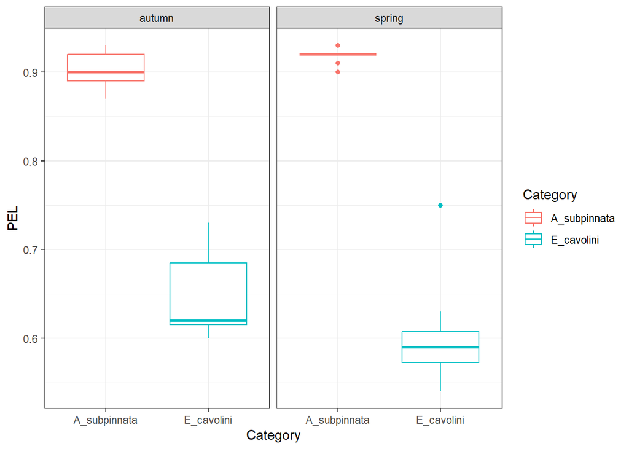

```r
resource.boxplot.1<-ggplot(subset(mm.data, Category == "A_subpinnata" | Category == "E_cavolini"), aes(x=Category, group = Category, y=PEL, colour=Category)) +
                  geom_boxplot() +
                  facet_grid(. ~ Season) +
                  theme_bw()
resource.boxplot.1
```

```r
# Resource boxplot corrected
mm.data$PELcorr<-mm.data$PEL
mm.data$PELcorr[mm.data$PELcorr < 0]<-0
mm.data$PELcorr[mm.data$PELcorr > 1]<-1
head(mm.data)
```

```
##   Season              Type          Category d15N  d13C Weight   mgN   mgC
## 1 autumn pico-nanoplankton pico-nanoplankton  3.4 -23.5   10.1 0.006 0.040
## 2 autumn pico-nanoplankton pico-nanoplankton  3.1 -23.8   10.1 0.006 0.042
## 3 autumn pico-nanoplankton pico-nanoplankton  2.8 -23.9    9.6 0.005 0.037
## 4 autumn pico-nanoplankton pico-nanoplankton  3.4 -23.2   10.8 0.006 0.044
## 5 autumn pico-nanoplankton pico-nanoplankton  5.5 -23.9   10.6 0.009 0.054
## 6 autumn pico-nanoplankton pico-nanoplankton  5.6 -23.5   11.2 0.008 0.047
##         CN d13Cpel d15Npel d13Clit d15Nlit  PEL PELcorr
## 1 6.666667   -23.4     3.1    -1.6     3.4 1.00    1.00
## 2 7.000000   -23.4     3.1    -1.6     3.4 1.02    1.00
## 3 7.400000   -23.4     3.1    -1.6     3.4 1.02    1.00
## 4 7.333333   -23.4     3.1    -1.6     3.4 0.99    0.99
## 5 6.000000   -23.4     3.1    -1.6     3.4 1.02    1.00
## 6 5.875000   -23.4     3.1    -1.6     3.4 1.00    1.00
```

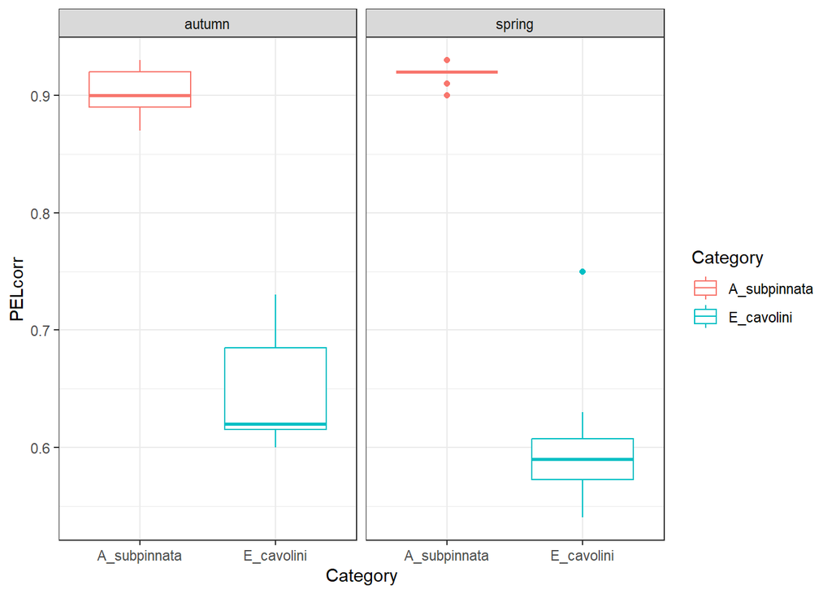

```r
resource.boxplot.2<-ggplot(subset(mm.data, Category == "A_subpinnata" | Category == "E_cavolini"), aes(x=Category, group = Category, y=PELcorr, colour=Category)) +
                  geom_boxplot() +
                  facet_grid(. ~ Season) +
                  theme_bw()
resource.boxplot.2
```

You just ran your first and simple stable isotope mixing model. At both seasons *A. subpinnata* assimilates predominantly pelagic resources compared with *E. cavolini*. Both species are segregated along a pelagic-littoral axis.

### Mixing models - three or more sources

- Cannot handle more than 2 sources
- No variation in sources
- No variation in enrichment factors (TEF)

To overcome these we need to use a model a bit more complicated:

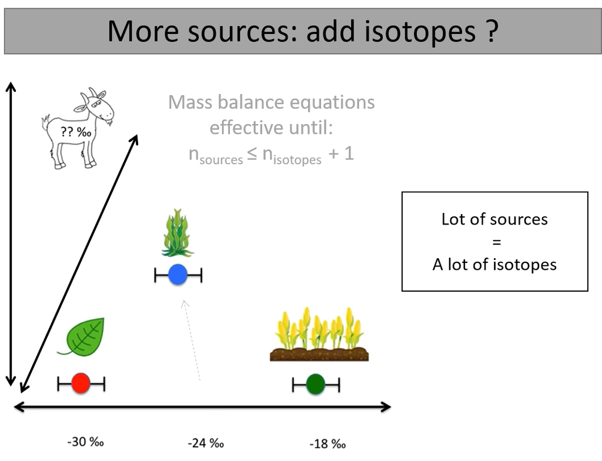

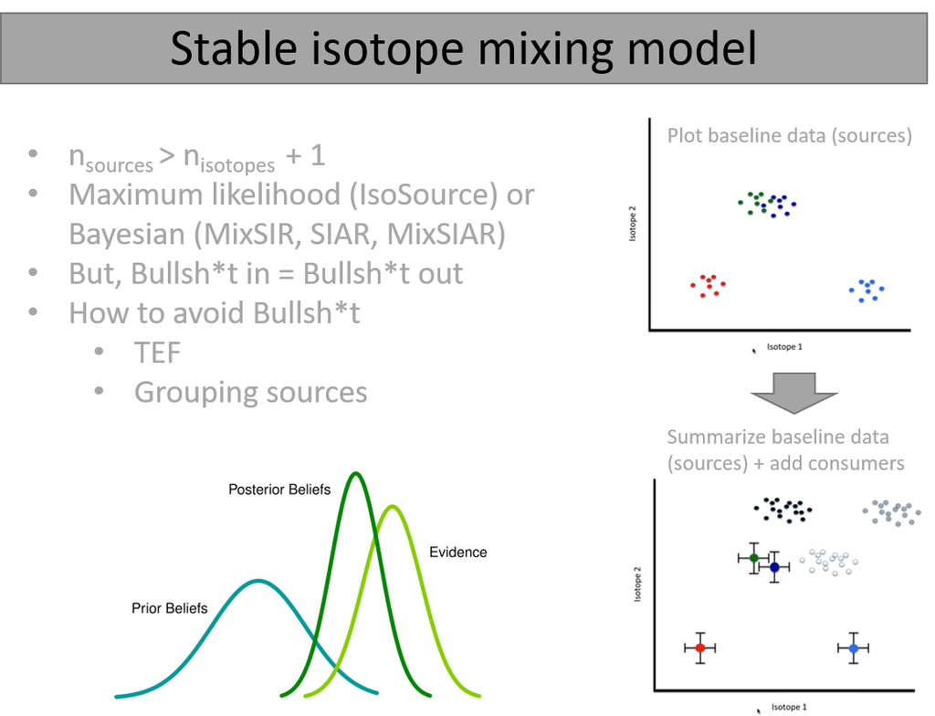

What to do when > 2 sources? Snowy story continued - Illustration adapted from Brian Hayden

`simmr` and `MixSIAR` are both packages designed to solve mixing equations for stable isotopic data within a Bayesian framework. Here `MixSIAR` has an advantage as it allows to run multiple models at the same time such as here the two seasons. Therefore for the purpose of the demonstration today, we will focus our effort on using the package `MixSIAR`.

#### MixSIAR - solving complex stable isotope mixing models

`MixSIAR` was developed by Brian Stock and is the result of a collaboration between Brice Semmens who developed `MixSIR` and Parnell et al. who developed `SIAR`. It is an incredibly powerful tool which can assess differences in resource use among different communities in a single model. It can be very complicated, and some of you better than I am in using this package. For the purpose of this demonstration we will just give a **brief introduction** to how to analyze our data set.

Here again, the code and notes are mostly extracted from materials shared by Brian Haydens. Himself credited Brian Stock and Brice Semmens who wrote a wonderful manual to accompany `MixSIAR` package [MixSIAR Manual](https://github.com/brianstock/MixSIAR/blob/master/Manual/mixsiar_manual_small.pdf). You can find it along with additional details about the package on GitHub (https://github.com/brianstock/MixSIAR) and the package is presented in Brians 2018 paper (https://peerj.com/article/5096.pdf).

##### **Write data**

You need a bit of manipulation here to format right the data sets that `MixSIAR` needs for the analysis. Here, we will compute all of them directly in R but you could also load them individually from files you prepare in Excel.

- Write mixture data (i.e consumers)

```r
### consumer data
Cons <- New.data # consumer data set
Cons[,c("Type", "Weight", "mgN", "mgC", "CN", "perc_C")]<-NULL
write.csv(Cons, "Data/Cons.csv", row.names=T)
# Note for Posit path "/cloud/project/Cons.csv" to ignore
```

- Write the sources

```r
Sub.data<-subset(Data, Category == "mesoplankton" | Category == "microplankton" | Category == "pico-nanoplankton" | Category == "sediment" )
Data.sum.2<-ddply(Sub.data, c("Season", "Category"), summarise,
                  Meand13C=mean(d13C, na.rm=T), #mean
                  SDd13C=sd(d13C, na.rm=T),#standard deviation
                  Meand15N=mean(d15N, na.rm=T),
                  SDd15N=sd(d15N, na.rm=T))

Sources<-Data.sum.2[,c(2,1,3,4,5,6)] # reshaping table
Sources$n<-rep(1000,8) # treating n as unknown (see MixSiAR manual)
write.csv(Sources, "Data/Sources.csv", row.names=F)
# Note for Posit path "/cloud/project/Sources.csv" to ignore
```

Note the difference in in n between d15N and d13C. Check `length(Data$d15N[!is.na(Data$d15N)])`and `length(Dataset$d13C[!is.na(Dataset$d13C)])`

- Write the TEFs

```r
Meand13C<-c(1.0, 1.0, 1.0,1.0)
SDd13C<-c(0.4, 0.4, 0.4, 0.4)
Meand15N<-c(2.5, 2.5, 2.5, 2.5)
SDd15N<-c(1, 1, 1, 1)
Tef<- data.frame(Meand13C, SDd13C, Meand15N, SDd15N)
rownames(Tef)<-c("mesoplankton" , "microplankton" , "pico-nanoplankton" , "sediment" )
write.csv(Tef, "Data/Tef.csv", row.names=T)
# Note for Posit path "/cloud/project/Tef.csv" to ignore
```

##### **Load data**

```r
# Consumers

mix <- load_mix_data(filename = "Data/Cons.csv", #"/cloud/project/Cons.csv"
                     iso_names = c("d13C","d15N"),
                     factors   = c("Season", "Category"),
                     fac_random = c(FALSE,FALSE), # very important here  T / F
                     fac_nested = c(TRUE,FALSE), # very important here F / T
                     cont_effects = NULL) # if you have gradient

# Sources

source <- load_source_data(filename = "Data/Sources.csv", #"/cloud/project/Sources.csv"
                           source_factors = "Season",
                           conc_dep = FALSE, # concentration dependent
                           data_type = "means",
                           mix)

# TEFs

discr <- load_discr_data(filename = "Data/Tef.csv", mix)
```

##### **Plot data**

This is your chance to check:

- Are the data loaded correctly?
- Is your mixture data in the source polygon?
- Are one or more of your sources confounded/hidden?

  `filename`: name you’d like MixSIAR to save the isospace plot as (extension will be added automatically)

  `plot_save_pdf`: TRUE or FALSE, should MixSIAR save the plot as a .pdf?

  `plot_save_png`: TRUE or FALSE, should MixSIAR save the plot as a .png?

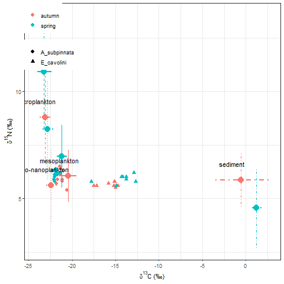

```r
# Make an isospace plot
plot_data(filename="Plots/isospace_plot", plot_save_pdf=FALSE, plot_save_png=TRUE, mix, source, discr)
```

You should *always* look at the isospace plot — this is a good check that the data is loaded correctly, and that the isospace geometry makes sense. If the mixture data are well outside the source polygon, you have a serious violation of mixing model assumptions, and it must be true that either 1) You’re missing a source, or 2) You’re using an incorrect discrimination factor. MixSIAR, like SIAR, fits a residual error term, and thus will always find a solution *even if it is nonsensical.*

Also note that the MixSIAR isospace plot adds the discrimination means AND SDs to the raw source values. This is because model uses the source + discrimination values to fit the mixture data, calculated as $\sqrt{\sigma^2_{source} + \sigma^2_{discr}}$, under the assumption of independence. Error bars indicate $\pm$ 1 SD.

##### **Plot prior**

Bayesian analyses require priors, and MixSIAR includes a `plot_prior` function to plot the prior on the mixture (diet) proportions (at the highest hierarchical level, p.global). The prior represents our **knowledge** about the proportions before we consider the biotracer data. A natural tendency is to want a flat/“uninformative” prior, where all values between 0 and 1 are equally likely. However, because proportions are not independent, there is no truly uninformative prior (e.g. the histograms are not flat). The best we can do with the Dirichlet distribution is set $\alpha$ = c(1,1,1,1), which is uninformative on the simplex. In other words, all combinations of the proportions are equally likely. See the section titled “Constructing informative Bayesian priors” in the forthcoming MixSIAR paper.

Because the mean of the “uninformative” prior, $\alpha$ = c(1,1,1,1), is $\frac{1}{n.sources}$, we also call it the generalist prior. This reflects two facts: 1) it is not really uninformative, and 2) for weakly informative data it shifts the posterior towards a generalist diet, $p_1 = p_2 = p_3 = p_4 = \frac{1}{4}$. The amount of shift depends on the informativeness (quality and quantity) of the data.

```
##
## -------------------------------------------------------------------------
## *** NOTE ***
##
## MixSIAR sorts the sources alphabetically. If you are using an informative
## prior, please check the plot to confirm that the sources you meant to give
## greater weight in the alpha vector receive greater weight in the prior.
## -------------------------------------------------------------------------
```

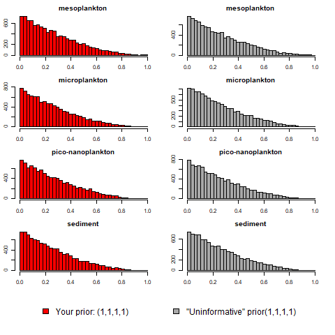

```r
# default "UNINFORMATIVE" / GENERALIST prior (alpha = 1)
plot_prior(filename="Plots/prior_plot", alpha.prior=c(1),source, plot_save_png = TRUE, plot_save_pdf=FALSE)
```

- RED = your prior
- DARK GREY = “uninformative”/generalist (alpha = 1 OR alpha = 1/n.sources )

Following is an example of informative prior:

```
##
## -------------------------------------------------------------------------
## *** NOTE ***
##
## MixSIAR sorts the sources alphabetically. If you are using an informative
## prior, please check the plot to confirm that the sources you meant to give
## greater weight in the alpha vector receive greater weight in the prior.
## -------------------------------------------------------------------------
```

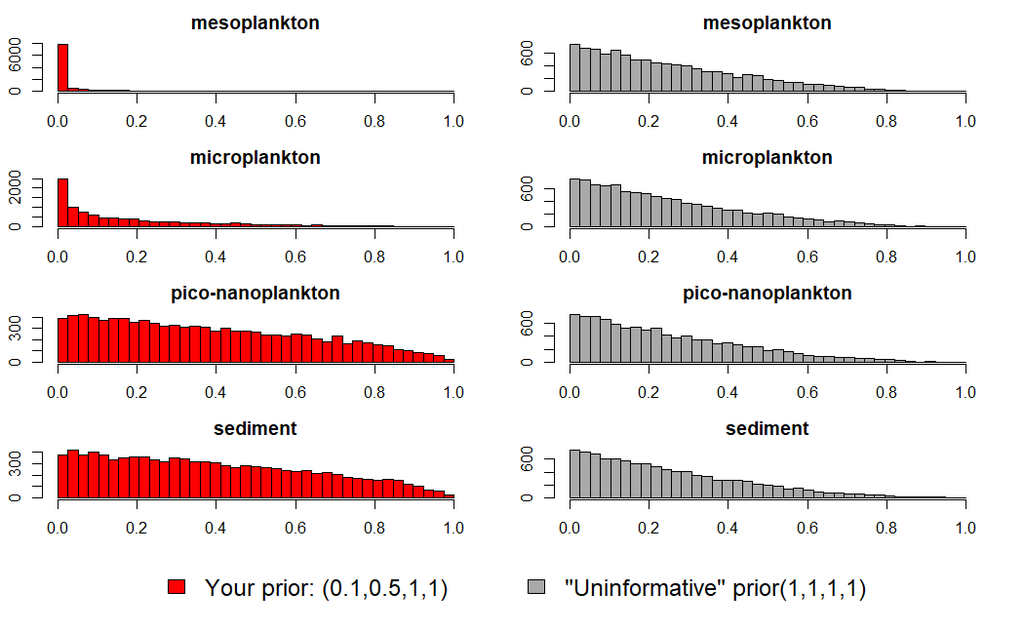

```r
# View an 'informative' prior
plot_prior(alpha.prior=c(0.1,0.5,1,1),source, plot_save_png = FALSE, plot_save_pdf=FALSE)
```

##### **Write JAGS model file**

Write the JAGS model file (define model structure). The model will be saved as `model_filename` (“MixSIAR_model.txt” is default, but you may want to change it if you create many different models). It will define the overall structure of the Markov Chain Monte Carlo (MCMC) model.

There are 3 error term options available:

1. Residual * Process (`resid_err = TRUE`, `process_err = TRUE`)
2. Residual only (`resid_err = TRUE`, `process_err = FALSE`)
3. Process only (`resid_err = FALSE`, `process_err = TRUE`)

The differences between “Residual * Process”, “Residual only”, and “Process only” are explained in [Stock and Semmens (2016)](https://esajournals.onlinelibrary.wiley.com/doi/10.1002/ecy.1517). If you have only 1 mix datapoint, you have no information about the mixture/consumer variability. In this case, we use the original MixSIR error model (which does not fit a residual error term). This is the same behavior as `siarsolo` in SIAR. Here, like in the **Wolves** example (see MixSIAR manual) we want the “Residual * Process” error option.

```r
# Write the JAGS model file
model_filename <- "MixSIAR_model.txt"   # Name of the JAGS model file
resid_err <- TRUE
process_err <- TRUE
write_JAGS_model(model_filename, resid_err, process_err, mix, source)
```

Our model is written, we now want to run it.

##### **Run model**

There are several pre-existing options to run your MCMC model:

| run | Chain Length | Burn-in | Thin | # Chains |
| --- | --- | --- | --- | --- |
| “test” | 1,000 | 500 | 1 | 3 |
| “very short” | 10,000 | 5,000 | 5 | 3 |
| “short” | 50,000 | 25,000 | 25 | 3 |
| “normal” | 100,000 | 50,000 | 50 | 3 |
| “long” | 300,000 | 200,000 | 100 | 3 |
| “very long” | 1,000,000 | 500,000 | 500 | 3 |
| “extreme” | 3,000,000 | 1,500,000 | 500 | 3 |

Alternatively, you can also set custom MCMC parameters, e.g:

```r
run <- list(chainLength=1000, burn=500, thin=1, chains=3, calcDIC=TRUE)
```

A good idea to use `run = "test"` at first to check if 1) all the data are loaded correctly and if 2) the model is specified correctly:

```r
# not run, youcan weight your priors in the lines below
jags.1 <- run_model(run="test", mix, source, discr, model_filename, alpha.prior = 1, resid_err, process_err)

# jags.1 <- run_model(run="normal", mix, source, discr, model_filename, alpha.prior = 1, resid_err, process_err)
```

```r
#not run
output_options <- list(summary_save = TRUE,
                       summary_name = "summary_statistics",
                       sup_post = FALSE,
                       plot_post_save_pdf = FALSE,
                       plot_post_name = "posterior_density",
                       sup_pairs = FALSE,
                       plot_pairs_save_pdf = FALSE,
                       plot_pairs_name = "pairs_plot",
                       sup_xy = FALSE, #
                       plot_xy_save_pdf = FALSE,
                       plot_xy_name = "xy_plot",
                       gelman = TRUE,
                       heidel = FALSE,
                       geweke = FALSE,
                       diag_save = TRUE,
                       diag_name = "diagnostics",
                       indiv_effect = FALSE,
                       plot_post_save_png = TRUE,
                       plot_pairs_save_png = FALSE,
                       plot_xy_save_png = FALSE)
```

Then you can call `output_JAGS` to process diagnostics, summary statistics, and create posterior density plots:

```
##  [1] ""
##  [2] "################################################################################"
##  [3] "# Gelman-Rubin Diagnostic"
##  [4] "################################################################################"
##  [5] ""
##  [6] "Generally the Gelman diagnostic should be < 1.05"
##  [7] ""
##  [8] ""
##  [9] "Out of 61 variables: 15 > 1.01"
## [10] ""
## [11] "                      "
## [12] "0 > 1.05"
## [13] ""
## [14] "                      "
## [15] "0 > 1.1"
```

[output cut: 81 more lines]

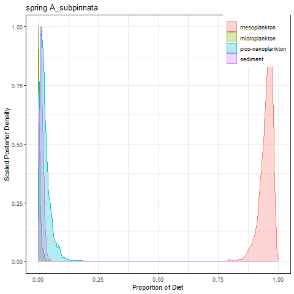

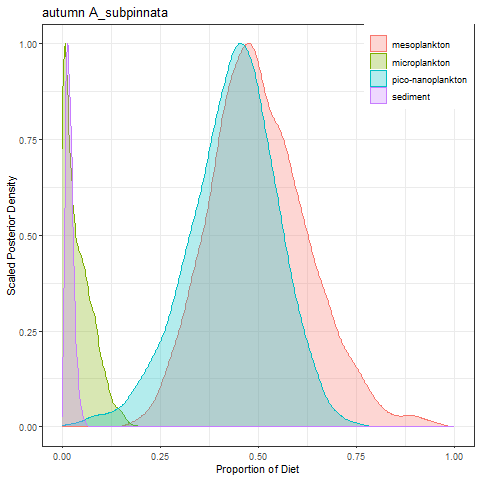

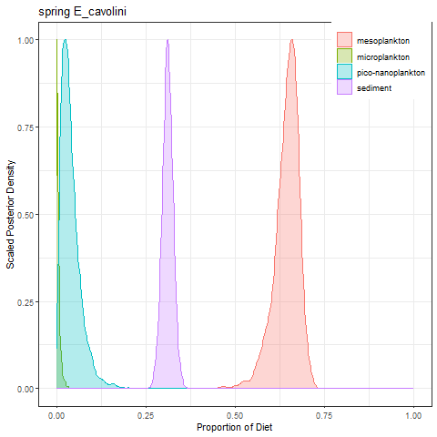

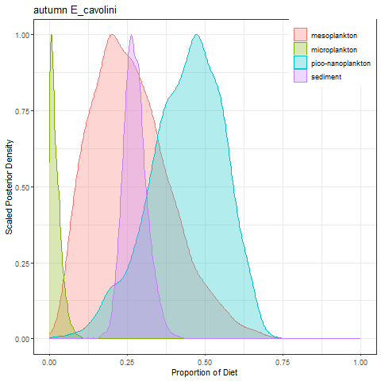

Scaled proportion density of coral diet

```r
# not run, figures from model output "normal"
output_JAGS(jags.1, mix, source, output_options)
```

For a thorough explanation of the output from `output_JAGS`, see the Wolves Example section of the [MixSIAR Manual](https://github.com/brianstock/MixSIAR/blob/master/inst/mixsiar_manual_3.1_small.pdf). You will also find examples of accessing the MCMC chains for post hoc plotting and analysis there.

More on MCMC at https://youtu.be/vTUwEu53uzs?feature=shared.

## The isotopic niches

To characterize isotopic niches, we will run `SIBER` analyses. Here again, thanks to Brian Hayden for the amazing materials. The scripts are predominantly taken from an example by Andrew Jackson, available [here](https://cran.r-project.org/web/packages/SIBER/vignettes/Introduction-to-SIBER.html)

Here again, the first task is to take back our original data set and to make some basic manipulations. The SIBER package isn’t quite as flexible as some of the others we have worked with so far. For SIBER analysis we need to code all data as *community* (in this case `Season`) and *group* (in this case ‘Category’). In addition, d13C and d15N **MUST** be named iso1 and iso2.

First an overview of the data set:

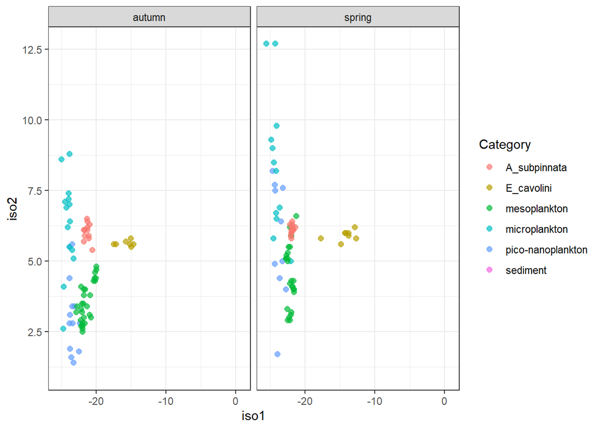

```r
#Siber biplots
Siber.biplots<-ggplot(Data, aes(x = d13C, y = d15N, colour = Category)) +
  geom_point(alpha = 0.7, size=2) +
  facet_grid(. ~ Season) +
  theme_bw() +
  ylab("iso2") +
  xlab("iso1")

Siber.biplots
```

For this analysis we are specifically interested in calculating and comparing the isotopic niche of the two coral species, *A. subpinnata* and *E. cavolini*. So we need to subset them out from the data set:

```r
# Subset coral
Siber.group<-subset(Dataset, Category == "A_subpinnata" | Category == "E_cavolini")[,c("d13C", "d15N", "Category", "Season")]
head(Siber.group)
```

```
##      d13C d15N     Category Season
## 109 -20.6  5.4 A_subpinnata autumn
## 110 -21.3  6.1 A_subpinnata autumn
## 111 -21.1  5.9 A_subpinnata autumn
## 112 -21.7  6.1 A_subpinnata autumn
## 113 -21.4  6.5 A_subpinnata autumn
## 114 -21.7  5.9 A_subpinnata autumn
```

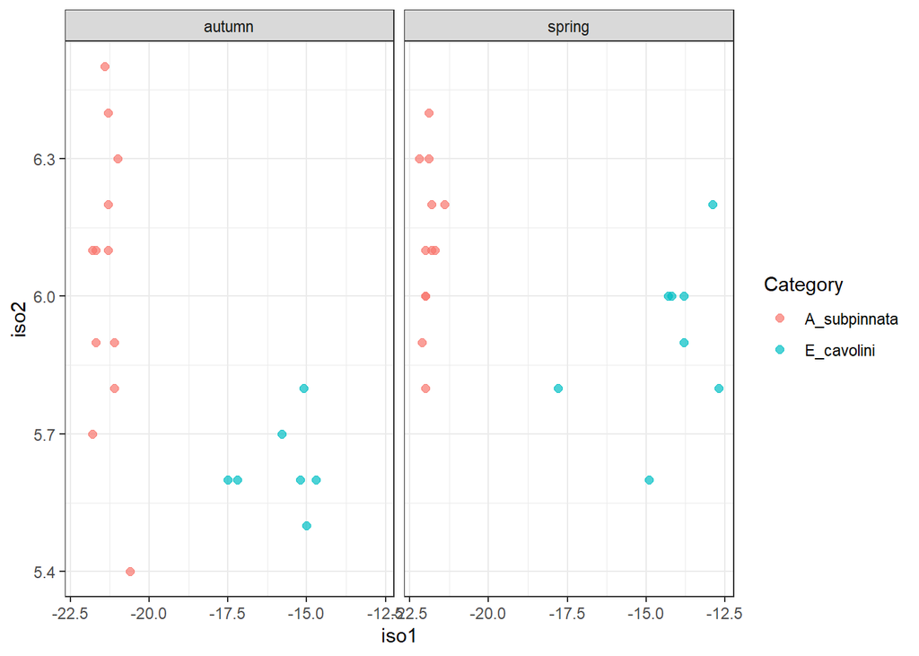

```r
# Siber group biplots
Siber.group.biplots<-ggplot(Siber.group, aes(x = d13C, y = d15N, colour = Category)) +
  geom_point(alpha = 0.7, size=2) +
  facet_grid(. ~ Season) +
  theme_bw() +
  ylab("iso2") +
  xlab("iso1")

Siber.group.biplots
```

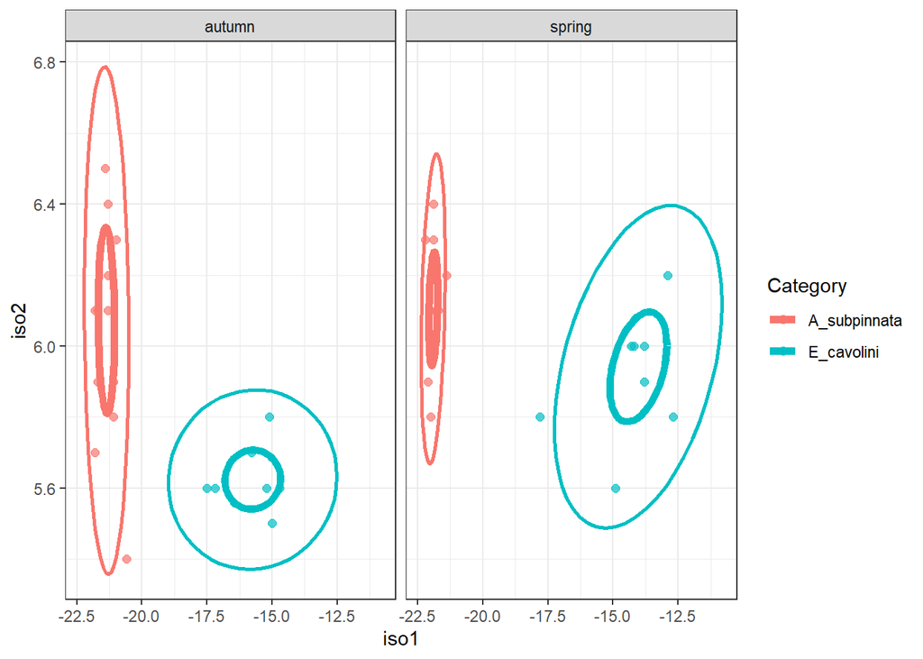

```r
# Add ellipses

Siber.group.biplots+
  stat_ellipse(position="identity", level=0.4, linewidth=2)+
  stat_ellipse(position="identity", level=0.95, linewidth=1)
```

Then some magic to start running the analysis! The `SIBER` package requires the data set in a specific format, *i.e.* a SIBER object. After renaming the variables, we can use the function `createSiberObject()` to create this object.

```r
# Variable name requirment SIBER + create SIBER object
colnames(Siber.group) <- c('iso1','iso2','group', 'community')
Siber.g.example <- createSiberObject(Siber.group)
```

The next step is to generate some SIBER plots of the data, to do this we need to provide the package with some specified argument terms before generating the plot. Here, we will use default options, but we still need to enter them. Try changing some of these arguments and see what effect this has on your plots!

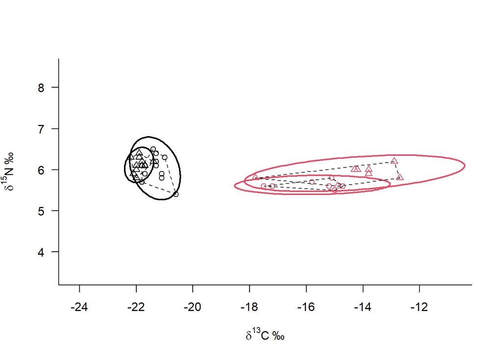

```r
# Create lists of plotting arguments to be passed onwards to each of the three plotting functions.
# Plot SIBER data

community.hulls.args <- list(col = 1, lty = 0, lwd = 1)
group.ellipses.args  <- list(n = 100, p.interval = 0.95, lty = 1, lwd = 2)
group.hull.args      <- list(lty = 2, col = "grey20")

par(mfrow=c(1,1))

plotSiberObject(Siber.g.example,
                  ax.pad = 2,
                  hulls = F, community.hulls.args,
                  ellipses = T, group.ellipses.args,
                  group.hulls = T, group.hull.args,
                  bty = "L",
                  iso.order = c(1,2),
                  xlab = expression({delta}^13*C~'\u2030'),
                  ylab = expression({delta}^15*N~'\u2030')
                  )
```

Okay, so we have now visualized the isotopic niche of each population but how about getting some data. We can obtain the convex hull area (TA), Standard Ellipse Area (SEA) and Standard Ellipse Area corrected (SEAc) based on the maximum likelihood estimates of the means and covariance matrices of each group.

```r
# Calculate summary statistics for each group: TA, SEA and SEAc
Group.ML <- groupMetricsML(Siber.g.example)
print(Group.ML)
```

```
##      autumn.A_subpinnata autumn.E_cavolini spring.A_subpinnata
## TA             0.7600000         0.4200000           0.2600000
## SEA            0.3453942         0.3338386           0.1118952
## SEAc           0.3799336         0.4006063           0.1230847
##      spring.E_cavolini
## TA           1.5300000
## SEA          0.8168449
## SEAc         0.9529857
```

Estimate ellipse overlap

```r
# The overlap of the maximum likelihood fitted standard ellipses are
# estimated using
A_subpinnata.overlap <- maxLikOverlap("autumn.A_subpinnata", "spring.A_subpinnata", Siber.g.example,
                              p.interval = NULL, n = 100)
A_subpinnata.overlap
```

```
##     area.1     area.2    overlap
## 0.37967859 0.12300208 0.00486988
```

```r
# the overlap between the corresponding 95% prediction ellipses is given by

A_subpinnata.95.overlap <- maxLikOverlap("autumn.A_subpinnata", "spring.A_subpinnata", Siber.g.example,
                                      p.interval = 0.95, n = 100)
A_subpinnata.95.overlap
```

```
##    area.1    area.2   overlap
## 2.2748308 0.7369626 0.6293039
```

```r
# so in this case, the overlap as a proportion of the non-overlapping area of
# the two ellipses, would be

A_subpinnata.over <- A_subpinnata.overlap[3] / (A_subpinnata.overlap[2] +
                                          A_subpinnata.overlap[1] -
                                         A_subpinnata.overlap[3])
A_subpinnata.over
```

```
##     overlap
## 0.009782592
```

```r
# repeat for other species

# The overlap of the maximum likelihood fitted standard ellipses are
# estimated using
E_cavolini.overlap <- maxLikOverlap("autumn.E_cavolini", "spring.E_cavolini", Siber.g.example,
                                      p.interval = NULL, n = 100)
E_cavolini.overlap
```

```
##      area.1      area.2     overlap
## 0.400337414 0.952346090 0.002374745
```

```r
E_cavolini.95.overlap <- maxLikOverlap("autumn.E_cavolini", "spring.E_cavolini", Siber.g.example,
                                      p.interval = 0.95, n = 100)
E_cavolini.95.overlap
```

```
##   area.1   area.2  overlap
## 2.398607 5.705948 1.995921
```

```r
E_cavolini.over <- E_cavolini.overlap[3] / (E_cavolini.overlap[2] +
                                          E_cavolini.overlap[1] -
                                         E_cavolini.overlap[3])
E_cavolini.over
```

```
##     overlap
## 0.001758668
```

These data are just **single value** however, e.g. geometric measurements of the area of each hull or ellipse. If want to know how reliable those data are we need to calculate a **confidence interval**. The best way to do that is by calculating the Bayesian ellipse (SEAb).

To do this we run the SIBER model again, first we need to provide model parameters and priors, we enter the default options are below

```r
# default model
parms <- list()
parms$n.iter <- 2 * 10^4   # number of iterations to run the model for
parms$n.burnin <- 1 * 10^3 # discard the first set of values
parms$n.thin <- 10     # thin the posterior by this many
parms$n.chains <- 2        # run this many chains

# default priors
priors <- list()
priors$R <- 1 * diag(2)
priors$k <- 2
priors$tau.mu <- 1.0E-3

# run the model
ellipses.posterior <- siberMVN(Siber.g.example, parms, priors) # MVN: Multivariate Normal distribution
```

The model ran successfully, next let’s look at the output:

[figure not shown]

```r
SEA.B <- siberEllipses(ellipses.posterior)

siberDensityPlot(SEA.B,
                xticklabels = c('Aut sub', 'Spr sub', 'Aut cav', 'Spr cav'),
                xlab = c("Community | Group"),
                ylab = expression("Standard Ellipse Area " ('\u2030' ^2) ),
                bty = "L",
                las = 1,
                main = "SIBER ellipses on each group"
                )

# Add red x's for the ML estimated SEA-c
points(1:ncol(SEA.B), Group.ML[3,], col="red", pch = "x", lwd = 2)
```

Visualizing the data is all well and good, show me the data (note: can skip this part)!

```r
# Calculate some credible intervals
cr.p <- c(0.95, 0.99) # vector of quantiles

# do similar to get the modes, taking care to pick up multimodal posterior
# distributions if present
SEA.B.modes <- lapply(
  as.data.frame(SEA.B),
  function(x,...){tmp<-hdrcde::hdr(x)$mode},
  prob = cr.p, all.modes=T)
SEA.B.modes
```

```
## $V1
## [1] 0.3280828
##
## $V2
## [1] 0.3053359
##
## $V3
## [1] 0.1036061
##
## $V4
## [1] 0.7591973
```

```r
# call to hdrcde:hdr using lapply()
SEA.B.credibles <- lapply(
  as.data.frame(SEA.B),
  function(x,...){tmp<-hdrcde::hdr(x)$hdr},
  prob = cr.p)
SEA.B.credibles
```

```
## $V1
##          [,1]      [,2]
## 99% 0.1403478 0.7896000
## 95% 0.1771100 0.6079066
## 50% 0.2675843 0.4007088
##
## $V2
##          [,1]      [,2]
## 99% 0.1065780 0.9884546
## 95% 0.1347466 0.7282787
## 50% 0.2357539 0.3995137
##
## $V3
##           [,1]      [,2]
## 99% 0.04566270 0.2490559
## 95% 0.05805399 0.1983883
## 50% 0.08352728 0.1275129
##
## $V4
##          [,1]     [,2]
## 99% 0.2798232 2.248512
## 95% 0.3614799 1.664317
## 50% 0.6065745 1.005666
```

## Food web

Can stable isotope ratios provide for community-wide measure of trophic structure? The **Layman** metrics:

**Nr** - d15N range; trophic height of food web

**Cr** - d13C range; breath of resource use

**TA** - total area; size of food web in delta-space

**CD** - Mean distance to centroid; trophic diversity within food web

**NND** - Mean ‘nearest neighbor distance’; food web packing

**SDNND** - SD ‘nearest neighbor distance’; food web packing

We will strat from our previous biplot `Siber.biplots`, but instead of analysing the isotopic niche of the two species of interest, here we are interested in the entire community however so everything stays!

```r
# Subset coral
Siber.comm<-Data[,c("d13C", "d15N", "Category", "Season")]
colnames(Siber.comm) <- c('iso1','iso2','group', 'community')
```

A **big problem** here is the presence of `NA` values. For the purpose of this demo, we will work around this problem by replacing missing values with average of the treatment (community|group).

```r
# A bit of cooking to remove the NA values
Siber.comm.corr<-Siber.comm %>%
  group_by(group, community) %>%
  mutate_at(vars(iso1, iso2), ~replace_na(., mean(., na.rm = TRUE)))

Siber.comm.corr<-as.data.frame(Siber.comm.corr)

# Creating SIBER object
Siber.c.example <- createSiberObject(Siber.comm.corr)
Siber.c.example$sample.sizes
```

```
##        A_subpinnata E_cavolini mesoplankton microplankton pico-nanoplankton
## autumn           12          7           29            15                15
## spring           12          8           25            12                12
##        sediment
## autumn        9
## spring        9
```

You need a minimum of 3 individuals in each group to run the analysis. If this is not the case, you should considering merging groups. As with the isotopic niche calculation we can calculate food web metrics according to the geometric distance between observed data points or using the Bayesian approach which will allow us to estimate the variance on each metric. Lets start with the easy stuff. As before, you need to provide some arguments for the plots and calculations.

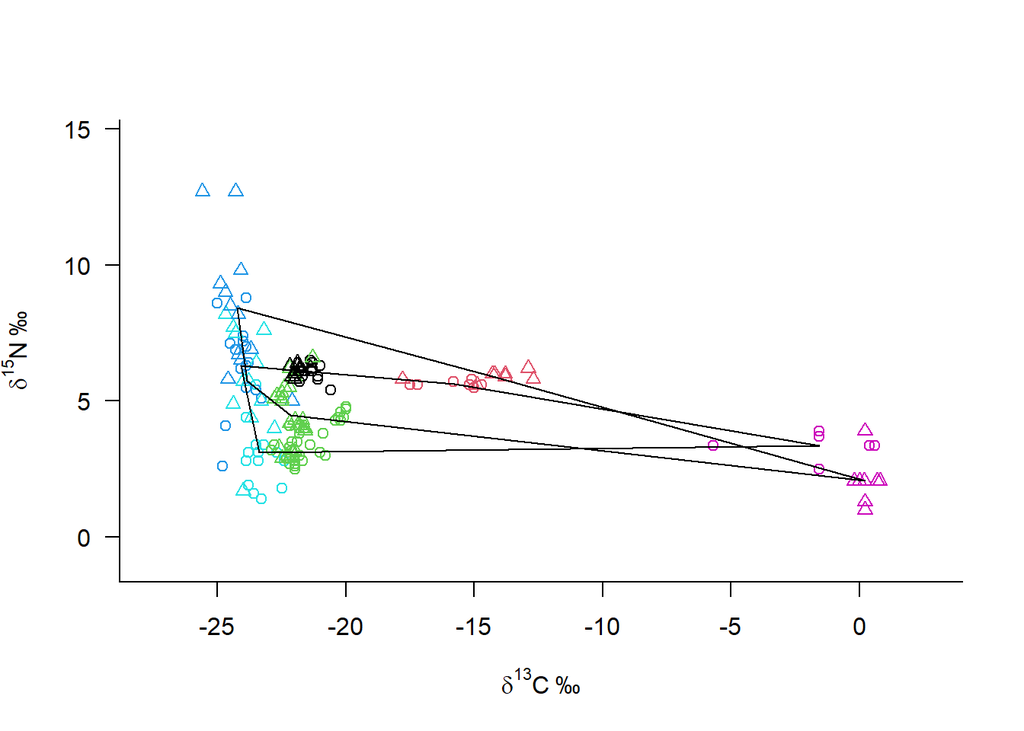

```r
# Create lists of plotting arguments to be passed onwards to each
# of the three plotting functions.
community.hulls.args <- list(col = 1, lty = 1, lwd = 1)

par(mfrow=c(1,1))
plotSiberObject(Siber.c.example,
                ax.pad = 2,
                hulls = T, community.hulls.args,
                ellipses = F, group.ellipses.args,
                group.hulls = F, group.hull.args,
                bty = "L",
                iso.order = c(1,2),
                xlab=expression({delta}^13*C~'\u2030'),
                ylab=expression({delta}^15*N~'\u2030'),
                cex = 0.5,
                )
```

```r
community.ML <- communityMetricsML(Siber.c.example)
print(community.ML)
```

```
##             autumn    spring
## dY_range  3.191758  6.358333
## dX_range 22.540000 24.466667
## TA       39.498825 44.616467
## CD        6.365794  7.302549
## MNND      4.860439  5.107563
## SDNND     4.862392  5.359845
```

Next, we can already see differences between each season but how reliable are they? To find out we run the SIBER model and calculate the Bayesian community metrics

```r
parms <- list()
parms$n.iter <- 2 * 10^4   # number of iterations to run the model for
parms$n.burnin <- 1 * 10^3 # discard the first set of values
parms$n.thin <- 10     # thin the posterior by this many
parms$n.chains <- 2        # run this many chains

# define the priors
priors <- list()
priors$R <- 1 * diag(2)
priors$k <- 2
priors$tau.mu <- 1.0E-3

ellipses.posterior <- siberMVN(Siber.c.example, parms, priors) #run the model
```

Success!

We can first plot the metrics for community 1, autumn.

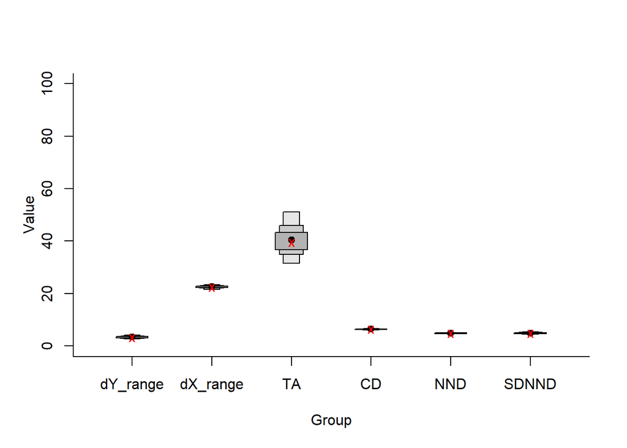

```r
# extract the posterior means
mu.post <- extractPosteriorMeans(Siber.c.example, ellipses.posterior)

# calculate the corresponding distribution of layman metrics
layman.B <- bayesianLayman(mu.post)


# --------------------------------------
# Visualise the first community
# --------------------------------------
siberDensityPlot(layman.B[[1]], xticklabels = colnames(layman.B[[1]]),
                bty="L", ylim = c(0,100))

# add the ML estimates (if you want). Extract the correct means
# from the appropriate array held within the overall array of means.
comm1.layman.ml <- laymanMetrics(Siber.c.example$ML.mu[[1]][1,1,],
                                 Siber.c.example$ML.mu[[1]][1,2,]
                                 )
points(1:6, comm1.layman.ml$metrics, col = "red", pch = "x", lwd = 2)
```

Visualise community 2, Spring

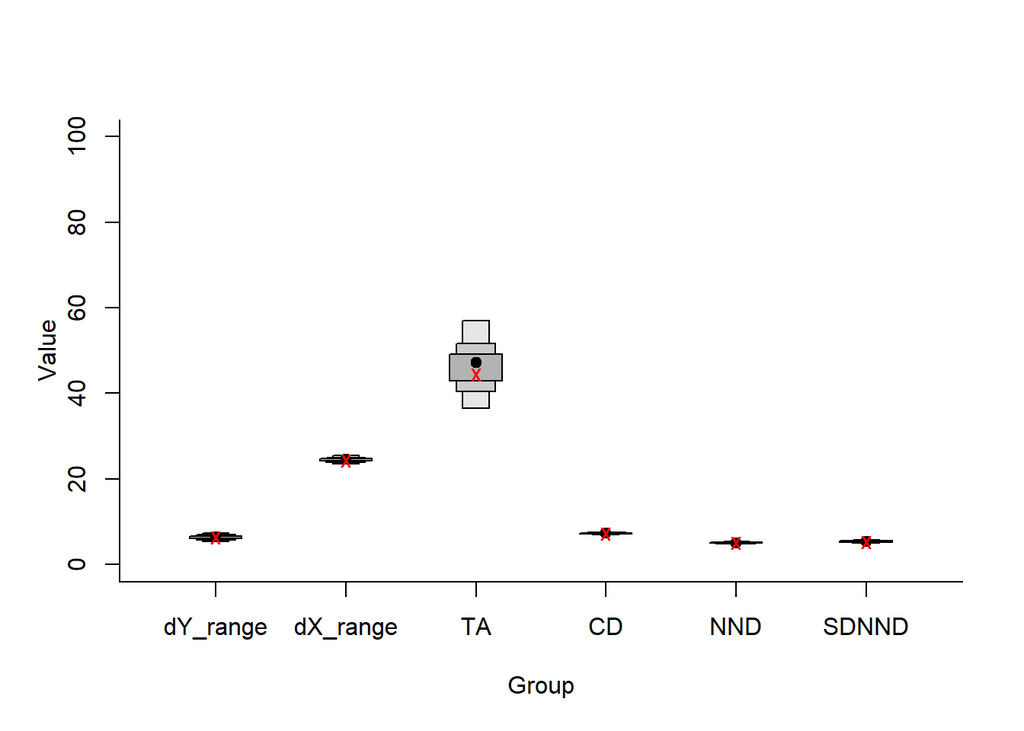

```r
# --------------------------------------
# Visualise the second community
# --------------------------------------
siberDensityPlot(layman.B[[2]], xticklabels = colnames(layman.B[[2]]),
                bty="L", ylim = c(0,100))

# add the ML estimates. (if you want) Extract the correct means
# from the appropriate array held within the overall array of means.
comm2.layman.ml <- laymanMetrics(Siber.c.example$ML.mu[[2]][1,1,],
                                 Siber.c.example$ML.mu[[2]][1,2,]
)
points(1:6, comm2.layman.ml$metrics, col = "red", pch = "x", lwd = 2)
```

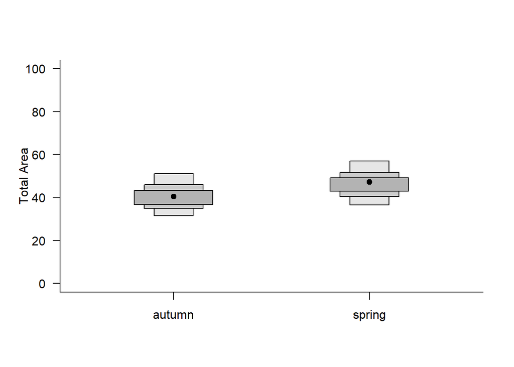

```r
par(mfrow=c(1,1))

siberDensityPlot(cbind(layman.B[[1]][,"TA"], layman.B[[2]][,"TA"]),
                xticklabels = c("autumn", "spring"),
                bty="L",
                ylim = c(0,100),
                las = 1,
                ylab = "Total Area",
                xlab = "")
```

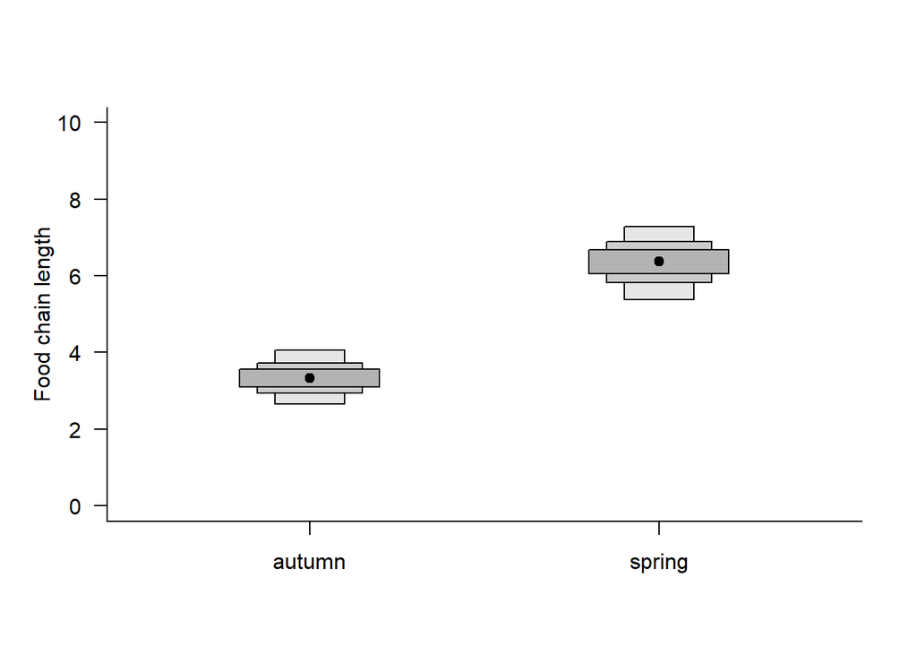

```r
siberDensityPlot(cbind(layman.B[[1]][,"dY_range"], layman.B[[2]][,"dY_range"]),
                xticklabels = c("autumn", "spring"),
                bty="L", ylim = c(0,10),
                las = 1,
                ylab = "Food chain length",
                xlab = "")
```

All Layman metrics increase in the spring: + complexity + resilient. **HOWEVER**, we have here strong limitation because of the NAs for which we did a bit of magic. Generally speaking, we also have too few samples for reliable intepretation